# Number of indexed/deindexed/active journals in the SciELO network

This analysis shows the annual evolution of the number of indexed, deindexed and active journals of each collection, and of the whole network.

```python
import matplotlib.pyplot as plt
import numpy as np
import pandas as pd
import seaborn as sns
```

```python
%matplotlib inline
```

## Loading the dataset

We're going to use the network `journals.csv` for that.

```python
journals = pd.read_csv("tabs_network/journals.csv")
```

The following ISSN cleaning/normalization step is fully documented in a normalization-specific notebook that can be found together with this one in the same repository.

```python
issn_scielo_fix = {"0001-6002": "0001-6012",
                   "0258-6444": "2215-3535",
                   "0325-8203": "1668-7027",
                   "0719-448x": "0719-448X",
                   "0797-9789": "1688-499X",
                   "0807-8967": "0870-8967",
                   "0858-6444": "0258-6444",
                   "1315-5216": "1316-5216",
                   "1667-8682": "1667-8982",
                   "1678-5177": "0103-6564",
                   "1683-0789": "1683-0768",
                   "1688-4094": "1688-4221",
                   "1852-4418": "1852-4184",
                   "1980-5438": "0103-5665",
                   "2175-3598": "0104-1282",
                   "2233-7666": "2223-7666",
                   "2237-101X": "1518-3319",
                   "24516600": "2451-6600",
                   "2993-6797": "2393-6797"}
journals["ISSN SciELO"].replace(issn_scielo_fix, inplace=True)
```

We don't need all the columns from the `journals.csv`.

```python
journals.columns
```

```
Index(['extraction date', 'study unit', 'collection', 'ISSN SciELO', 'ISSN's',
       'title at SciELO', 'title thematic areas',
       'title is agricultural sciences', 'title is applied social sciences',
       'title is biological sciences', 'title is engineering',
       'title is exact and earth sciences', 'title is health sciences',
       'title is human sciences', 'title is linguistics, letters and arts',
       'title is multidisciplinary', 'title current status',
       'title + subtitle SciELO', 'short title SciELO', 'short title ISO',
       'title PubMed', 'publisher name', 'use license', 'alpha frequency',
       'numeric frequency (in months)', 'inclusion year at SciELO',
       'stopping year at SciELO', 'stopping reason',
       'date of the first document', 'volume of the first document',
       'issue of the first document', 'date of the last document',
       'volume of the last document', 'issue of the last document',
       'total of issues', 'issues at 2018', 'issues at 2017', 'issues at 2016',
       'issues at 2015', 'issues at 2014', 'issues at 2013',
       'total of regular issues', 'regular issues at 2018',
       'regular issues at 2017', 'regular issues at 2016',
       'regular issues at 2015', 'regular issues at 2014',
       'regular issues at 2013', 'total of documents', 'documents at 2018',
       'documents at 2017', 'documents at 2016', 'documents at 2015',
       'documents at 2014', 'documents at 2013', 'citable documents',
       'citable documents at 2018', 'citable documents at 2017',
       'citable documents at 2016', 'citable documents at 2015',
       'citable documents at 2014', 'citable documents at 2013',
       'portuguese documents at 2018 ', 'portuguese documents at 2017 ',
       'portuguese documents at 2016 ', 'portuguese documents at 2015 ',
       'portuguese documents at 2014 ', 'portuguese documents at 2013 ',
       'spanish documents at 2018 ', 'spanish documents at 2017 ',
       'spanish documents at 2016 ', 'spanish documents at 2015 ',
       'spanish documents at 2014 ', 'spanish documents at 2013 ',
       'english documents at 2018 ', 'english documents at 2017 ',
       'english documents at 2016 ', 'english documents at 2015 ',
       'english documents at 2014 ', 'english documents at 2013 ',
       'other language documents at 2018 ',
       'other language documents at 2017 ',
       'other language documents at 2016 ',
       'other language documents at 2015 ',
       'other language documents at 2014 ',
       'other language documents at 2013 ', 'google scholar h5 2018 ',
       'google scholar h5 2017 ', 'google scholar h5 2016 ',
       'google scholar h5 2015 ', 'google scholar h5 2014 ',
       'google scholar h5 2013 ', 'google scholar m5 2018 ',
       'google scholar m5 2017 ', 'google scholar m5 2016 ',
       'google scholar m5 2015 ', 'google scholar m5 2014 ',
       'google scholar m5 2013 '],
      dtype='object')
```

These are the columns we need:

```python
columns = ["collection", "ISSN SciELO",
           "inclusion year at SciELO", "stopping year at SciELO"]
journals[columns].head()
```

|  | collection | ISSN SciELO | inclusion year at SciELO | stopping year at SciELO |
| --- | --- | --- | --- | --- |
| 0 | scl | 1676-5648 | 2006 | 2010.0 |
| 1 | scl | 0101-8108 | 2004 | 2012.0 |
| 2 | scl | 0034-7701 | 2000 | 2008.0 |
| 3 | scl | 0102-261X | 1999 | 2012.0 |
| 4 | scl | 1516-9332 | 2005 | 2009.0 |

```python
journals[columns].shape
```

```
(1732, 4)
```

## Collections

Are there any inactive collection in the analytics?

```python
url = "http://articlemeta.scielo.org/api/v1/collection/identifiers/"
collections_info = pd.read_json(url)
collections_info[collections_info["has_analytics"] &
                 ~collections_info["is_active"]].code
```

```
9    sss
Name: code, dtype: object
```

Yes! The `sss` (Social Sciences) collection is discontinued. The easiest way to collect information from this dataset is by removing its entries, but in order to get the full network information and the information about this collection, we shouldn't do that.

How can we classify these collections?

```python
collections_info[collections_info["has_analytics"]] \
    .groupby("status").aggregate({"code": set})
```

| status | code |
| --- | --- |
| certified | {sss, mex, per, arg, cri, sza, prt, esp, cub, ... |
| development | {pry, ecu} |
| independent | {rvt, psi, rve} |

The `independent` collections follow the SciELO model, but they aren't managed by SciELO.

We have $5$ collections in analytics that are *thematic*:

```python
acolinfo = collections_info[collections_info["has_analytics"]] \
                           [["code", "document_count", "domain",
                             "original_name", "status", "is_active"]] \
                           .set_index("code")
acolinfo.loc[["psi", "rve", "rvt", "spa", "sss"]]
```

| code | document_count | domain | original_name | status | is_active |
| --- | --- | --- | --- | --- | --- |
| psi | 23841.0 | pepsic.bvsalud.org | PEPSIC | independent | True |
| rve | 22733.0 | www.revenf.bvs.br | REVENF | independent | True |
| rvt | 136.0 | www.revtur.org | RevTur | independent | True |
| spa | 40996.0 | www.scielosp.org | Saúde Pública | certified | True |
| sss | 665.0 | socialsciences.scielo.org | Social Sciences | certified | False |

```python
acolinfo.drop(["psi", "rve", "rvt", "spa", "sss"])
```

| code | document_count | domain | original_name | status | is_active |
| --- | --- | --- | --- | --- | --- |
| arg | 36555.0 | www.scielo.org.ar | Argentina | certified | True |
| chl | 61760.0 | www.scielo.cl | Chile | certified | True |
| col | 66973.0 | www.scielo.org.co | Colombia | certified | True |
| cub | 33492.0 | scielo.sld.cu | Cuba | certified | True |
| esp | 37200.0 | scielo.isciii.es | España | certified | True |
| mex | 56905.0 | www.scielo.org.mx | Mexico | certified | True |
| prt | 17127.0 | www.scielo.mec.pt | Portugal | certified | True |
| scl | 370150.0 | www.scielo.br | Brasil | certified | True |
| sza | 25617.0 | www.scielo.org.za | South Africa | certified | True |
| ven | 18971.0 | www.scielo.org.ve | Venezuela | certified | True |
| bol | 4758.0 | www.scielo.org.bo | Bolivia | certified | True |
| cri | 9158.0 | www.scielo.sa.cr | Costa Rica | certified | True |
| per | 9618.0 | www.scielo.org.pe | Peru | certified | True |
| pry | NaN | scielo.iics.una.py | Paraguay | development | True |
| ury | 4360.0 | www.scielo.edu.uy | Uruguay | certified | True |
| ecu | 15.0 | www.scielo.ec | Ecuador | development | True |

## Data de-duplication & `inf` instead of `NaN`

Each ISSN may appear in more than one collection and perhaps more than once in a collection, as the `ISSN SciELO` column is normalized, not the rows. As an example of that:

```python
journals[columns][journals["ISSN SciELO"].isin(["0103-5665", "0104-1282"])]
```

|  | collection | ISSN SciELO | inclusion year at SciELO | stopping year at SciELO |
| --- | --- | --- | --- | --- |
| 60 | scl | 0103-5665 | 2006 | 2015.0 |
| 1442 | psi | 0103-5665 | 2015 | 2015.0 |
| 1455 | psi | 0104-1282 | 2012 | NaN |
| 1461 | psi | 0103-5665 | 2008 | NaN |
| 1492 | psi | 0104-1282 | 2008 | NaN |

These rows are inconsistent, as the inclusion year is different for the same ISSN. At least, these are the only inconsistent entries in the dataset:

```python
is_consistent = (
    journals[columns]
        .groupby(["collection", "ISSN SciELO"])
        .apply(lambda df: df.apply(set).apply(len).sum() == df.size)
        .rename("is_consistent")
)
pd.DataFrame(is_consistent[~is_consistent])
```

| collection | ISSN SciELO | is_consistent |
| --- | --- | --- |
| psi | 0103-5665 | False |
|  | 0104-1282 | False |

Then let's get the consistent dataset while keeping the index in "sync" with the full journals dataframe. We'll replace the `NaN` by `inf` (infinity) in the stopping year column in order to make it the greates possible value (which will also be required later on).

```python
dataset = (journals
    .reset_index()
    .fillna({"stopping year at SciELO": np.inf})
    .groupby(["collection", "ISSN SciELO"])
    .aggregate({
        "inclusion year at SciELO": "min",
        "stopping year at SciELO": "max",
        "index": "max",
    })
    .reset_index()
    .set_index("index")
)
dataset.iloc[::312]
```

| index | collection | ISSN SciELO | inclusion year at SciELO | stopping year at SciELO |
| --- | --- | --- | --- | --- |
| 373 | arg | 0002-7014 | 2003 | 2014.000000 |
| 725 | col | 0120-3592 | 2006 | inf |
| 1006 | esp | 0211-5735 | 2007 | inf |
| 1284 | prt | 0873-2159 | 2006 | 2012.000000 |
| 277 | scl | 0102-6909 | 1998 | inf |
| 1571 | sss | 1414-3283 | 2006 | inf |

The previous cell has a quite generic code that should work on any input. But in our case, it could be simpler, since only two rows had been removed (as expected):

```python
dataset.shape
```

```
(1730, 4)
```

The duplicated entries were fixed:

```python
dataset[dataset["ISSN SciELO"].isin(["0103-5665", "0104-1282"])]
```

| index | collection | ISSN SciELO | inclusion year at SciELO | stopping year at SciELO |
| --- | --- | --- | --- | --- |
| 1461 | psi | 0103-5665 | 2008 | inf |
| 1492 | psi | 0104-1282 | 2008 | inf |
| 60 | scl | 0103-5665 | 2006 | 2015.000000 |

A simpler (but not recommended) approach would be the removal of the two duplicated rows: $1442$ and $1455$, in the 2018-09-14 package version. ($1436$ and $1449$ in the 2018-06-10 package version).

```python
journals.drop([1442, 1455]).shape
```

```
(1730, 98)
```

Is it really the same?

```python
journals.drop([1442, 1455])[columns].fillna(np.inf).eq(dataset).all()
```

```
collection                  True
ISSN SciELO                 True
inclusion year at SciELO    True
stopping year at SciELO     True
dtype: bool
```

## Number of active journals in the network

How many active journals does the network have?

```python
dataset[dataset["stopping year at SciELO"] == np.inf]["ISSN SciELO"] \
    .drop_duplicates().count()
```

```
1360
```

Actually, that number isn't *clean*, since a journal can't be said *active* just because it's was never deindexed in a now discontinued collection.

### Social Sciences (`sss`) collection normalization

There are $10$ journals from the `sss` collection that could be regarded as deindexed from the year when `sss` was discontinued.

```python
dataset[(dataset["stopping year at SciELO"] == np.inf) &
        (dataset["collection"] != "sss")]["ISSN SciELO"] \
    .drop_duplicates().count()
```

```
1350
```

That's another kind of normalization step: enforcing that the `sss` collection had all its entries deindexed in $2010$.

```python
sss_discontinuation_year = 2010
sss_selector = dataset[dataset["collection"] == "sss"].index
# The "max" step is just for consistency
# regarding an extraordinary entry included in 2017
dataset.loc[sss_selector, "stopping year at SciELO"] = \
    dataset[dataset["collection"] == "sss"].T.apply(
        lambda row: max(min(sss_discontinuation_year,
                            row["stopping year at SciELO"]),
                        row["inclusion year at SciELO"])
    )
```

### Yearly totals

How many journals had been active in the past years? In order to answer this question, we'll need to count how many journals had been indexed and deindexed on each year, grouping them to de-duplicate when any journal appears in more than one collection.

```python
network_years = dataset.groupby(["ISSN SciELO"]).aggregate({
    "inclusion year at SciELO": "min",
    "stopping year at SciELO": "max",
})
network_years.head()
```

| ISSN SciELO | inclusion year at SciELO | stopping year at SciELO |
| --- | --- | --- |
| 0001-3714 | 1999 | 2000.000000 |
| 0001-3765 | 2000 | inf |
| 0001-6012 | 2002 | inf |
| 0001-6365 | 2001 | 2012.000000 |
| 0002-0591 | 2013 | 2015.000000 |

```python
network_index = pd.DataFrame({
    "indexed": network_years.groupby("inclusion year at SciELO").size(),
    "deindexed": network_years.groupby("stopping year at SciELO").size(),
}).fillna(0) \
  .assign(total=lambda df: (df["indexed"] - df["deindexed"]).cumsum()) \
  .drop(np.inf)
network_index
```

|  | indexed | deindexed | total |
| --- | --- | --- | --- |
| 1997.0 | 9.0 | 1.0 | 8.0 |
| 1998.0 | 29.0 | 0.0 | 37.0 |
| 1999.0 | 15.0 | 1.0 | 51.0 |
| 2000.0 | 28.0 | 3.0 | 76.0 |
| 2001.0 | 26.0 | 2.0 | 100.0 |
| 2002.0 | 67.0 | 5.0 | 162.0 |
| 2003.0 | 43.0 | 3.0 | 202.0 |
| 2004.0 | 57.0 | 5.0 | 254.0 |
| 2005.0 | 83.0 | 10.0 | 327.0 |
| 2006.0 | 132.0 | 6.0 | 453.0 |
| 2007.0 | 121.0 | 9.0 | 565.0 |
| 2008.0 | 100.0 | 14.0 | 651.0 |
| 2009.0 | 100.0 | 8.0 | 743.0 |
| 2010.0 | 134.0 | 15.0 | 862.0 |
| 2011.0 | 103.0 | 10.0 | 955.0 |
| 2012.0 | 106.0 | 56.0 | 1005.0 |
| 2013.0 | 124.0 | 23.0 | 1106.0 |
| 2014.0 | 98.0 | 23.0 | 1181.0 |
| 2015.0 | 89.0 | 15.0 | 1255.0 |
| 2016.0 | 64.0 | 16.0 | 1303.0 |
| 2017.0 | 90.0 | 53.0 | 1340.0 |
| 2018.0 | 35.0 | 25.0 | 1350.0 |

The totals are the difference of the cumulative sum of the indexed/deindexed columns. Numbers might be difficult to understand, let's plot this data.

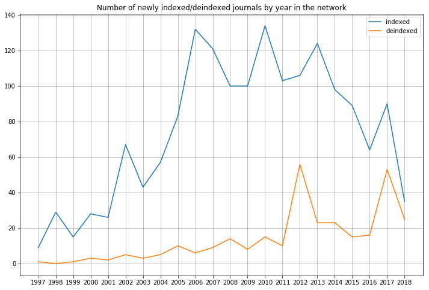

```python
network_index[["indexed", "deindexed"]].plot(
    figsize=(12, 8),
    title="Number of newly indexed/deindexed journals by year in the network",
    xticks=network_index.index,
    grid=True,
);
```

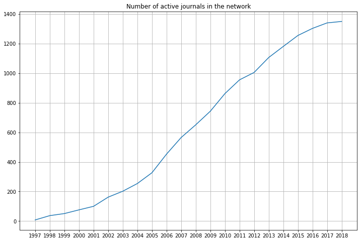

```python
network_index["total"].plot(
    figsize=(12, 8),
    title="Number of active journals in the network",
    xticks=network_index.index,
    grid=True,
);
```

## Why are the journals deindexed?

There are $3$ possible reasons for that:

- Suspended, a journal that hadn't been satisfying some quality/requirement criteria (e.g. data access is no longer open, had one year delay)
- Deceased, a journal that stopped publishing at all
- Renamed, it became another journal entry (the old entry is regarded as deceased)

Can we find this information in this dataset?

There are two columns/fields that might help here:

```python
journals["title current status"].unique()
```

```
array(['deceased', 'suspended', 'current', 'inprogress'], dtype=object)
```

```python
journals["stopping reason"].unique()
```

```
array([nan, 'susp', 'not-'], dtype=object)
```

These mean:

- `NaN`: Not deindexed, deceased or renamed. It's an empty field in the CSV;
- `"susp"`: Suspended by either the editor or the committee;
- `"not-"`: Suspended since the access is no longer open.

### How many had been deindexed by these reasons?

Regarding the `stopping reason` column, that evaluation only makes sense for deindexed journals, since every indexed journal has `NaN` as the reason:

```python
# Number of reasons different than NaN for not deindexed journals
journals[journals["stopping year at SciELO"] == np.inf] \
        ["stopping reason"].count()
```

```
0
```

Let's summarize the information from this column and the `title current status` column:

```python
reasons = (journals
    .assign(active=journals["stopping year at SciELO"].isna())
    .fillna({"stopping year at SciELO": np.inf,
             "stopping reason": ""})
    .groupby(["ISSN SciELO"])
    .aggregate({
        "inclusion year at SciELO": "min",
        "stopping year at SciELO": "max",
        "stopping reason": frozenset,
        "title current status": frozenset,
        "active": "max",
    })
    .groupby(["stopping reason", "title current status", "active"])
    .size()
    .rename("count")
    .reorder_levels(["active", "title current status", "stopping reason"])
    .sort_index()
)
pd.DataFrame(reasons)
```

| active | title current status | stopping reason | count |
| --- | --- | --- | --- |
| False | (deceased) | () | 124 |
|  | (suspended) | (susp) | 163 |
|  |  | (not-) | 6 |
| True | (current) | () | 1337 |
|  | (deceased, current) | () | 3 |
|  | (current, suspended) | (, susp) | 15 |
|  |  | (, not-) | 1 |
|  | (deceased, current, suspended) | (, susp) | 1 |
|  | (inprogress) | () | 1 |
|  | (current, inprogress) | () | 2 |

We don't need to care about the several alternatives in `True` since there are journals that are no longer active in one collection while it's still active in another collection, the only consistency check we can perform there is the sum, it should be the total of active journals.

```python
pd.DataFrame(reasons).unstack(0).sum()
```

```
       active
count  False      293.0
       True      1360.0
dtype: float64
```

The proportion of deindexed reasons can be shown in a bar plot:

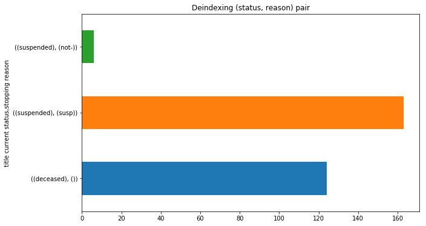

```python
reasons.loc[False].plot.barh(
    title="Deindexing (status, reason) pair",
    figsize=(10, 6)
);
```

## Collection-specific analysis

In the data de-duplication section, we had already normalized the rows to ensure every entry has a distinct ISSN. If we hadn't, now that would need to be done in order to properly count the entries of each collection.

Yearly, how many journals had been indexed for each collection? Let's see the cumulative number of journals indexed until a certain year for every collection.

```python
indexed_on = (
    dataset
    .groupby(["inclusion year at SciELO", "collection"])
    .size()
    .unstack()
    .fillna(0)
    .sort_index(axis=1)
    .sort_index()
)
indexed_on.cumsum().astype(int)
```

| collection inclusion year at SciELO | arg | bol | chl | col | cri | cub | ecu | esp | mex | per | prt | psi | rve | rvt | scl | spa | sss | sza | ury | ven |
| --- | --- | --- | --- | --- | --- | --- | --- | --- | --- | --- | --- | --- | --- | --- | --- | --- | --- | --- | --- | --- |
| 1997 | 0 | 0 | 0 | 0 | 0 | 0 | 0 | 0 | 0 | 0 | 0 | 0 | 0 | 0 | 9 | 0 | 0 | 0 | 0 | 0 |
| 1998 | 0 | 0 | 12 | 0 | 0 | 0 | 0 | 0 | 0 | 0 | 0 | 0 | 0 | 0 | 25 | 2 | 0 | 0 | 0 | 0 |
| 1999 | 0 | 0 | 13 | 0 | 0 | 2 | 0 | 1 | 1 | 0 | 0 | 0 | 0 | 0 | 35 | 5 | 0 | 0 | 0 | 0 |
| 2000 | 0 | 0 | 20 | 0 | 0 | 4 | 0 | 1 | 1 | 0 | 0 | 0 | 0 | 0 | 54 | 5 | 0 | 0 | 0 | 0 |
| 2001 | 0 | 0 | 25 | 0 | 0 | 4 | 0 | 4 | 1 | 0 | 0 | 0 | 0 | 0 | 66 | 6 | 0 | 0 | 0 | 5 |
| 2002 | 0 | 0 | 35 | 3 | 10 | 9 | 0 | 9 | 1 | 0 | 0 | 0 | 1 | 0 | 96 | 8 | 0 | 0 | 0 | 9 |
| 2003 | 3 | 0 | 39 | 3 | 10 | 10 | 0 | 13 | 1 | 0 | 3 | 1 | 1 | 0 | 115 | 8 | 0 | 0 | 0 | 17 |
| 2004 | 4 | 0 | 47 | 6 | 10 | 15 | 0 | 21 | 1 | 7 | 4 | 4 | 1 | 0 | 130 | 9 | 0 | 0 | 0 | 23 |
| 2005 | 17 | 0 | 56 | 7 | 10 | 17 | 0 | 25 | 6 | 8 | 8 | 26 | 1 | 0 | 147 | 12 | 4 | 0 | 0 | 26 |
| 2006 | 30 | 0 | 62 | 22 | 10 | 19 | 0 | 33 | 14 | 11 | 14 | 43 | 6 | 0 | 174 | 12 | 26 | 0 | 0 | 37 |
| 2007 | 48 | 0 | 69 | 47 | 10 | 22 | 0 | 35 | 19 | 12 | 19 | 60 | 10 | 0 | 204 | 13 | 28 | 0 | 0 | 44 |
| 2008 | 57 | 5 | 78 | 61 | 10 | 29 | 0 | 38 | 29 | 12 | 26 | 92 | 10 | 0 | 215 | 13 | 28 | 0 | 0 | 49 |
| 2009 | 69 | 8 | 85 | 78 | 10 | 33 | 0 | 40 | 43 | 15 | 27 | 109 | 10 | 0 | 228 | 13 | 31 | 7 | 0 | 51 |
| 2010 | 87 | 11 | 89 | 106 | 11 | 40 | 0 | 43 | 70 | 16 | 33 | 117 | 10 | 0 | 248 | 15 | 32 | 17 | 0 | 52 |
| 2011 | 94 | 16 | 99 | 121 | 14 | 42 | 0 | 45 | 92 | 16 | 39 | 119 | 11 | 0 | 271 | 16 | 32 | 23 | 0 | 53 |
| 2012 | 102 | 16 | 100 | 144 | 15 | 47 | 0 | 47 | 114 | 18 | 42 | 126 | 11 | 0 | 301 | 17 | 32 | 24 | 2 | 53 |
| 2013 | 107 | 17 | 105 | 162 | 18 | 52 | 0 | 54 | 132 | 19 | 50 | 132 | 11 | 0 | 330 | 17 | 32 | 39 | 4 | 56 |
| 2014 | 120 | 19 | 106 | 182 | 22 | 53 | 0 | 56 | 149 | 20 | 54 | 136 | 11 | 0 | 340 | 17 | 32 | 52 | 12 | 57 |
| 2015 | 123 | 19 | 107 | 204 | 27 | 61 | 0 | 58 | 171 | 23 | 59 | 139 | 11 | 0 | 344 | 18 | 32 | 62 | 14 | 57 |
| 2016 | 123 | 21 | 112 | 219 | 31 | 64 | 0 | 60 | 180 | 24 | 63 | 142 | 12 | 0 | 354 | 18 | 32 | 65 | 18 | 57 |
| 2017 | 137 | 22 | 115 | 227 | 39 | 67 | 2 | 60 | 201 | 29 | 66 | 145 | 17 | 3 | 362 | 20 | 33 | 67 | 24 | 58 |
| 2018 | 141 | 22 | 117 | 228 | 42 | 67 | 2 | 60 | 207 | 29 | 69 | 147 | 18 | 3 | 366 | 20 | 33 | 76 | 25 | 58 |

The number of indexed by year, instead of the cumulative values, can be seen in a heat map:

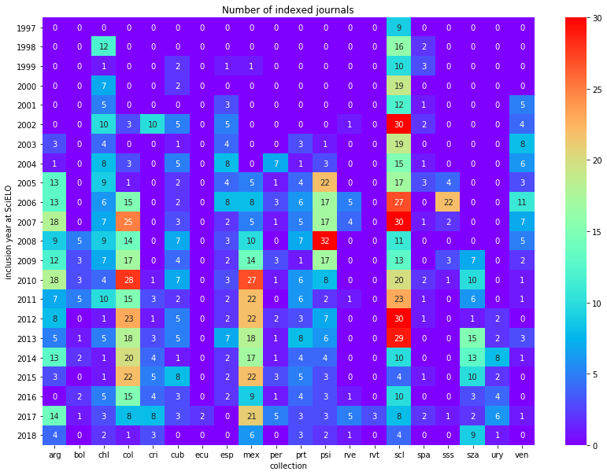

```python
sns.heatmap(indexed_on,
    cmap="rainbow", fmt="g", annot=True,
    vmin=0, vmax=30,
    ax=plt.subplots(figsize=(14, 10))[1]
).set(title="Number of indexed journals");
```

And the same regarding the deindexed entries:

```python
deindexed_on = (dataset
    .groupby(["stopping year at SciELO", "collection"])
    .size()
    .drop(np.inf)
    .unstack()
    .fillna(0)
    .sort_index(axis=1)
    .sort_index()
)
deindexed_on.cumsum().astype(int)
```

| collection stopping year at SciELO | arg | bol | chl | col | cri | cub | esp | mex | prt | psi | rve | scl | spa | sss | sza | ury | ven |
| --- | --- | --- | --- | --- | --- | --- | --- | --- | --- | --- | --- | --- | --- | --- | --- | --- | --- |
| 1997.0 | 0 | 0 | 0 | 0 | 0 | 0 | 0 | 0 | 0 | 0 | 0 | 1 | 0 | 0 | 0 | 0 | 0 |
| 1999.0 | 0 | 0 | 0 | 0 | 0 | 0 | 0 | 0 | 0 | 0 | 0 | 2 | 0 | 0 | 0 | 0 | 0 |
| 2000.0 | 0 | 0 | 0 | 0 | 0 | 0 | 0 | 0 | 0 | 0 | 0 | 5 | 0 | 0 | 0 | 0 | 0 |
| 2001.0 | 0 | 0 | 1 | 0 | 0 | 0 | 0 | 0 | 0 | 0 | 0 | 6 | 0 | 0 | 0 | 0 | 0 |
| 2002.0 | 0 | 0 | 4 | 0 | 0 | 0 | 0 | 0 | 0 | 0 | 0 | 8 | 0 | 0 | 0 | 0 | 0 |
| 2003.0 | 0 | 0 | 4 | 0 | 0 | 0 | 2 | 0 | 0 | 0 | 0 | 9 | 0 | 0 | 0 | 0 | 0 |
| 2004.0 | 0 | 0 | 4 | 0 | 0 | 0 | 3 | 0 | 0 | 1 | 0 | 12 | 0 | 0 | 0 | 0 | 0 |
| 2005.0 | 0 | 0 | 4 | 0 | 1 | 0 | 4 | 1 | 0 | 4 | 0 | 16 | 0 | 0 | 0 | 0 | 0 |
| 2006.0 | 1 | 0 | 5 | 0 | 2 | 0 | 5 | 2 | 0 | 5 | 0 | 16 | 0 | 0 | 0 | 0 | 0 |
| 2007.0 | 1 | 0 | 6 | 0 | 4 | 0 | 6 | 5 | 0 | 6 | 0 | 17 | 0 | 0 | 0 | 0 | 0 |
| 2008.0 | 1 | 0 | 9 | 0 | 4 | 0 | 9 | 5 | 0 | 16 | 0 | 19 | 0 | 0 | 0 | 0 | 0 |
| 2009.0 | 1 | 0 | 9 | 0 | 5 | 1 | 9 | 6 | 0 | 19 | 0 | 23 | 0 | 0 | 0 | 0 | 0 |
| 2010.0 | 1 | 0 | 11 | 0 | 5 | 1 | 9 | 6 | 2 | 20 | 0 | 26 | 0 | 32 | 0 | 0 | 0 |
| 2011.0 | 2 | 0 | 11 | 0 | 5 | 1 | 11 | 7 | 4 | 20 | 0 | 30 | 0 | 32 | 0 | 0 | 0 |
| 2012.0 | 2 | 0 | 11 | 0 | 5 | 3 | 13 | 7 | 9 | 33 | 0 | 46 | 0 | 32 | 0 | 0 | 20 |
| 2013.0 | 2 | 0 | 11 | 0 | 5 | 3 | 16 | 9 | 12 | 44 | 0 | 50 | 0 | 32 | 0 | 0 | 23 |
| 2014.0 | 5 | 0 | 11 | 0 | 5 | 3 | 16 | 18 | 13 | 53 | 0 | 54 | 0 | 32 | 0 | 0 | 23 |
| 2015.0 | 7 | 0 | 11 | 0 | 5 | 4 | 16 | 20 | 16 | 53 | 0 | 61 | 0 | 32 | 0 | 2 | 23 |
| 2016.0 | 7 | 2 | 11 | 0 | 5 | 6 | 16 | 25 | 16 | 53 | 3 | 66 | 0 | 32 | 0 | 2 | 23 |
| 2017.0 | 16 | 2 | 14 | 3 | 5 | 6 | 17 | 44 | 22 | 53 | 4 | 73 | 2 | 33 | 1 | 4 | 23 |
| 2018.0 | 23 | 2 | 14 | 4 | 5 | 6 | 17 | 57 | 22 | 54 | 4 | 75 | 2 | 33 | 1 | 5 | 23 |

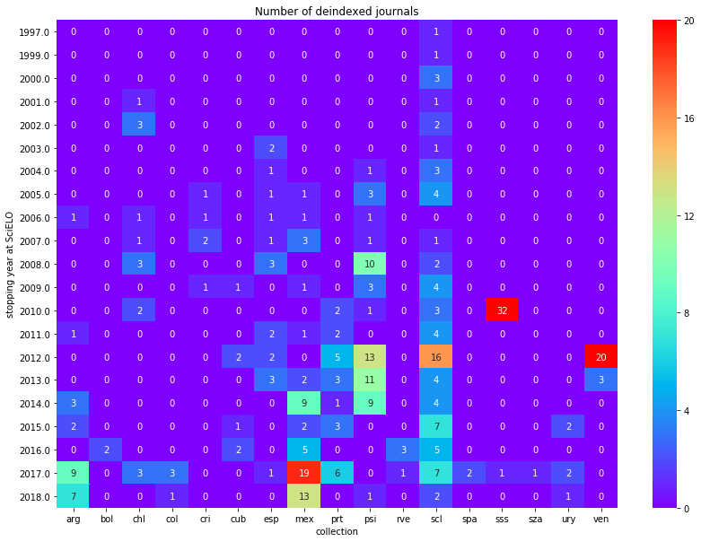

```python
sns.heatmap(deindexed_on,
    cmap="rainbow", fmt="g", annot=True,
    vmin=0, vmax=20,
    ax=plt.subplots(figsize=(14, 10))[1]
).set(title="Number of deindexed journals");
```

We can join these in a single table by stacking the collection as a secondary row index:

```python
indexed_deindexed_df = pd.DataFrame([
    indexed_on.stack().rename("indexed"),
    deindexed_on.stack().rename("deindexed"),
]).T.fillna(0)
indexed_deindexed_df.iloc[::31].astype(int)
```

|  |  | indexed | deindexed |
| --- | --- | --- | --- |
| 1997 | arg | 0 | 0 |
| 1998 | psi | 0 | 0 |
| 2000 | chl | 7 | 0 |
| 2001 | rvt | 0 | 0 |
| 2003 | cri | 0 | 0 |
| 2004 | spa | 1 | 0 |
| 2006 | ecu | 0 | 0 |
| 2007 | sza | 0 | 0 |
| 2009 | mex | 14 | 1 |
| 2010 | ven | 1 | 0 |
| 2012 | prt | 3 | 5 |
| 2014 | bol | 2 | 0 |
| 2015 | rve | 0 | 0 |
| 2017 | col | 8 | 3 |
| 2018 | scl | 4 | 2 |

That makes it easier to plot both information at once for a single collection, for example:

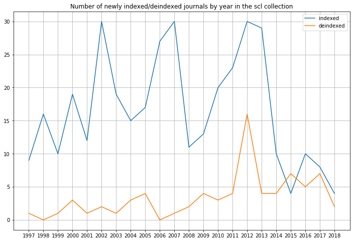

```python
indexed_deindexed_df.reorder_levels([1, 0]).loc["scl"].plot(
    figsize=(12, 8),
    title="Number of newly indexed/deindexed journals "
          "by year in the scl collection",
    xticks=range(1997, 2019),
    grid=True,
);
```

We can get the active journals for all the collections directly from the two dataframes with the indexed and deindexed counts:

```python
active_on = indexed_on.__sub__(deindexed_on, fill_value=0).cumsum()
active_on.astype(int)
```

| collection | arg | bol | chl | col | cri | cub | ecu | esp | mex | per | prt | psi | rve | rvt | scl | spa | sss | sza | ury | ven |
| --- | --- | --- | --- | --- | --- | --- | --- | --- | --- | --- | --- | --- | --- | --- | --- | --- | --- | --- | --- | --- |
| 1997 | 0 | 0 | 0 | 0 | 0 | 0 | 0 | 0 | 0 | 0 | 0 | 0 | 0 | 0 | 8 | 0 | 0 | 0 | 0 | 0 |
| 1998 | 0 | 0 | 12 | 0 | 0 | 0 | 0 | 0 | 0 | 0 | 0 | 0 | 0 | 0 | 24 | 2 | 0 | 0 | 0 | 0 |
| 1999 | 0 | 0 | 13 | 0 | 0 | 2 | 0 | 1 | 1 | 0 | 0 | 0 | 0 | 0 | 33 | 5 | 0 | 0 | 0 | 0 |
| 2000 | 0 | 0 | 20 | 0 | 0 | 4 | 0 | 1 | 1 | 0 | 0 | 0 | 0 | 0 | 49 | 5 | 0 | 0 | 0 | 0 |
| 2001 | 0 | 0 | 24 | 0 | 0 | 4 | 0 | 4 | 1 | 0 | 0 | 0 | 0 | 0 | 60 | 6 | 0 | 0 | 0 | 5 |
| 2002 | 0 | 0 | 31 | 3 | 10 | 9 | 0 | 9 | 1 | 0 | 0 | 0 | 1 | 0 | 88 | 8 | 0 | 0 | 0 | 9 |
| 2003 | 3 | 0 | 35 | 3 | 10 | 10 | 0 | 11 | 1 | 0 | 3 | 1 | 1 | 0 | 106 | 8 | 0 | 0 | 0 | 17 |
| 2004 | 4 | 0 | 43 | 6 | 10 | 15 | 0 | 18 | 1 | 7 | 4 | 3 | 1 | 0 | 118 | 9 | 0 | 0 | 0 | 23 |
| 2005 | 17 | 0 | 52 | 7 | 9 | 17 | 0 | 21 | 5 | 8 | 8 | 22 | 1 | 0 | 131 | 12 | 4 | 0 | 0 | 26 |
| 2006 | 29 | 0 | 57 | 22 | 8 | 19 | 0 | 28 | 12 | 11 | 14 | 38 | 6 | 0 | 158 | 12 | 26 | 0 | 0 | 37 |
| 2007 | 47 | 0 | 63 | 47 | 6 | 22 | 0 | 29 | 14 | 12 | 19 | 54 | 10 | 0 | 187 | 13 | 28 | 0 | 0 | 44 |
| 2008 | 56 | 5 | 69 | 61 | 6 | 29 | 0 | 29 | 24 | 12 | 26 | 76 | 10 | 0 | 196 | 13 | 28 | 0 | 0 | 49 |
| 2009 | 68 | 8 | 76 | 78 | 5 | 32 | 0 | 31 | 37 | 15 | 27 | 90 | 10 | 0 | 205 | 13 | 31 | 7 | 0 | 51 |
| 2010 | 86 | 11 | 78 | 106 | 6 | 39 | 0 | 34 | 64 | 16 | 31 | 97 | 10 | 0 | 222 | 15 | 0 | 17 | 0 | 52 |
| 2011 | 92 | 16 | 88 | 121 | 9 | 41 | 0 | 34 | 85 | 16 | 35 | 99 | 11 | 0 | 241 | 16 | 0 | 23 | 0 | 53 |
| 2012 | 100 | 16 | 89 | 144 | 10 | 44 | 0 | 34 | 107 | 18 | 33 | 93 | 11 | 0 | 255 | 17 | 0 | 24 | 2 | 33 |
| 2013 | 105 | 17 | 94 | 162 | 13 | 49 | 0 | 38 | 123 | 19 | 38 | 88 | 11 | 0 | 280 | 17 | 0 | 39 | 4 | 33 |
| 2014 | 115 | 19 | 95 | 182 | 17 | 50 | 0 | 40 | 131 | 20 | 41 | 83 | 11 | 0 | 286 | 17 | 0 | 52 | 12 | 34 |
| 2015 | 116 | 19 | 96 | 204 | 22 | 57 | 0 | 42 | 151 | 23 | 43 | 86 | 11 | 0 | 283 | 18 | 0 | 62 | 12 | 34 |
| 2016 | 116 | 19 | 101 | 219 | 26 | 58 | 0 | 44 | 155 | 24 | 47 | 89 | 9 | 0 | 288 | 18 | 0 | 65 | 16 | 34 |
| 2017 | 121 | 20 | 101 | 224 | 34 | 61 | 2 | 43 | 157 | 29 | 44 | 92 | 13 | 3 | 289 | 18 | 0 | 66 | 20 | 35 |
| 2018 | 118 | 20 | 103 | 224 | 37 | 61 | 2 | 43 | 150 | 29 | 47 | 93 | 14 | 3 | 291 | 18 | 0 | 75 | 20 | 35 |

```python
def add_markers_and_annotation(ax):
    # Apply the markers
    for line, marker in zip(ax.get_lines(), "ov^<>spP*hHxXDd8234+1.,"):
        line.set_marker(marker)
        col = line.get_label()
        x, y = line.get_data()
        x, y = x[:len(np.trim_zeros(y, "b"))], np.trim_zeros(y)
        x = x[-len(y):]
        line.set_data(x, y)
        ax.annotate(col, xy=(x[-1], y[-1]), xytext=(10,0),
                    textcoords="offset points")
    ax.legend()
```

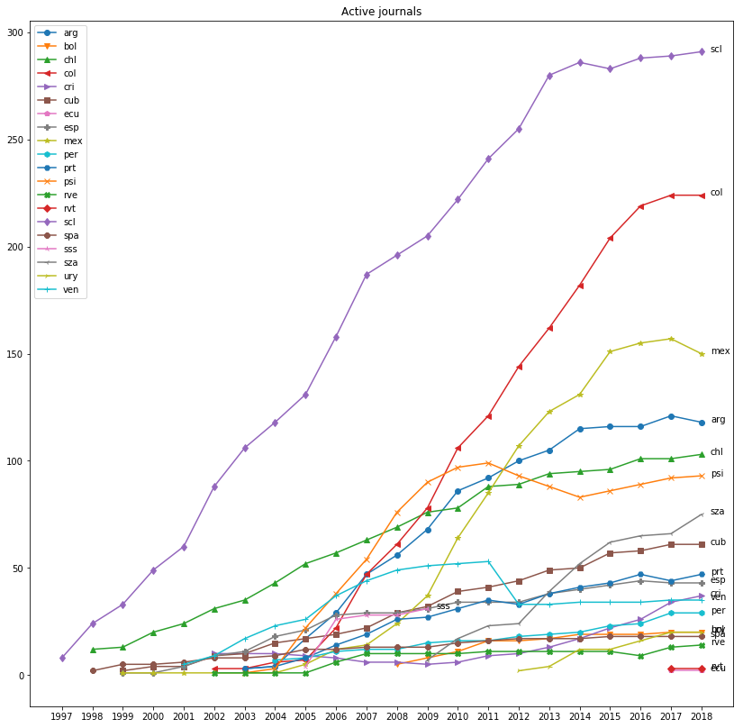

```python
active_on.plot(figsize=(14, 14), xticks=active_on.index,
               title="Active journals")
add_markers_and_annotation(plt.gca())
```

The total number of active journals in 2018 for each collection is:

```python
active_on.loc[2018].sort_values()
```

```
collection
sss      0.0
ecu      2.0
rvt      3.0
rve     14.0
spa     18.0
bol     20.0
ury     20.0
per     29.0
ven     35.0
cri     37.0
esp     43.0
prt     47.0
cub     61.0
sza     75.0
psi     93.0
chl    103.0
arg    118.0
mex    150.0
col    224.0
scl    291.0
Name: 2018, dtype: float64
```

Seeing just parts of the data:

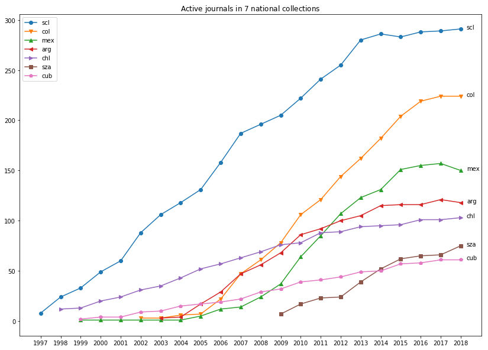

```python
active_on[["scl", "col", "mex", "arg", "chl", "sza", "cub"]] \
         .plot.line(figsize=(14, 10), xticks=active_on.index,
                    title="Active journals in $7$ national collections")
add_markers_and_annotation(plt.gca())
```

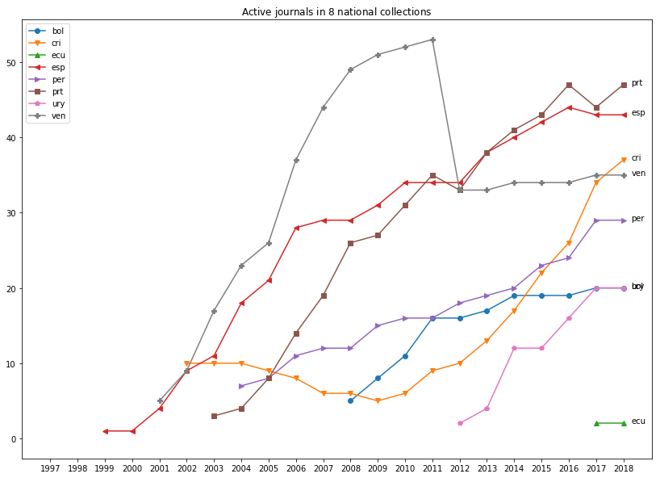

```python
active_on.drop(columns=["scl", "col", "mex", "arg", "chl", "sza", "cub",
                        "psi", "rve", "rvt", "spa", "sss"]) \
         .plot.line(figsize=(14, 10), xticks=active_on.index,
                    title="Active journals in $8$ national collections")
add_markers_and_annotation(plt.gca())
```

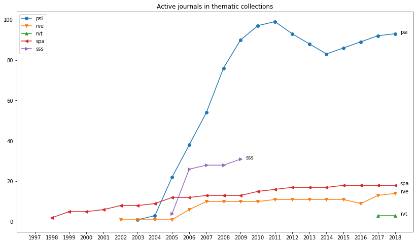

```python
active_on[["psi", "rve", "rvt", "spa", "sss"]] \
         .plot.line(figsize=(14, 8), xticks=active_on.index,
                    title="Active journals in thematic collections")
add_markers_and_annotation(plt.gca())
```

Or, a subplots visualization of it all (without markers):

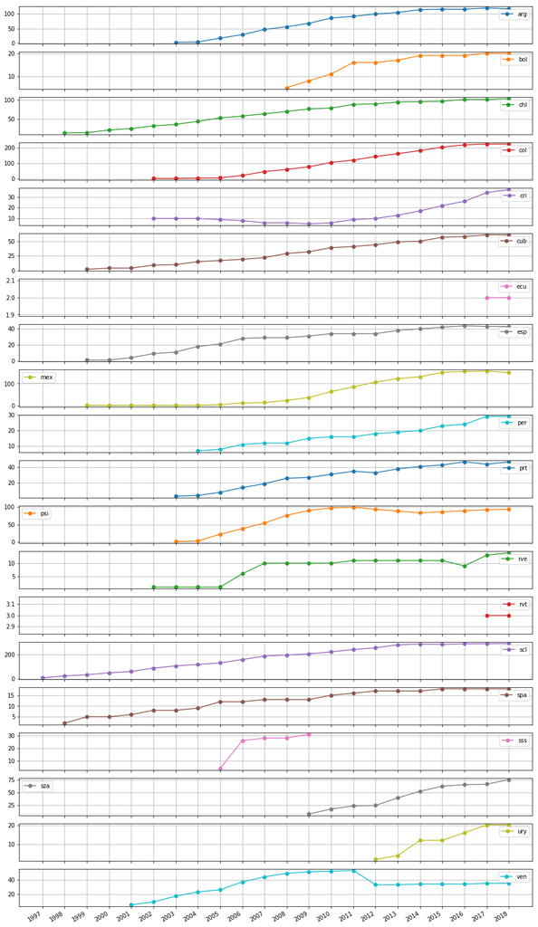

```python
# Replacing 0 by NaN only works because these have no zero in-between
active_on.replace(0, np.nan).plot(
    subplots=True,
    figsize=(16, 32),
    xticks=active_on.index,
    grid=True,
    marker="o",
);
```

## Summing the collection-specific entries

Usually we shouldn't sum the count of the collection-specific entries, because they have some intersection (the same ISSN) and that would add some residual to our results. To give some sense of how much residual is that, let's calculate it!

```python
collections_sum = active_on.T.sum()
collections_sum
```

```
1997       8.0
1998      38.0
1999      55.0
2000      80.0
2001     104.0
2002     169.0
2003     209.0
2004     262.0
2005     340.0
2006     477.0
2007     595.0
2008     689.0
2009     784.0
2010     884.0
2011     980.0
2012    1030.0
2013    1130.0
2014    1205.0
2015    1279.0
2016    1328.0
2017    1372.0
2018    1383.0
dtype: float64
```

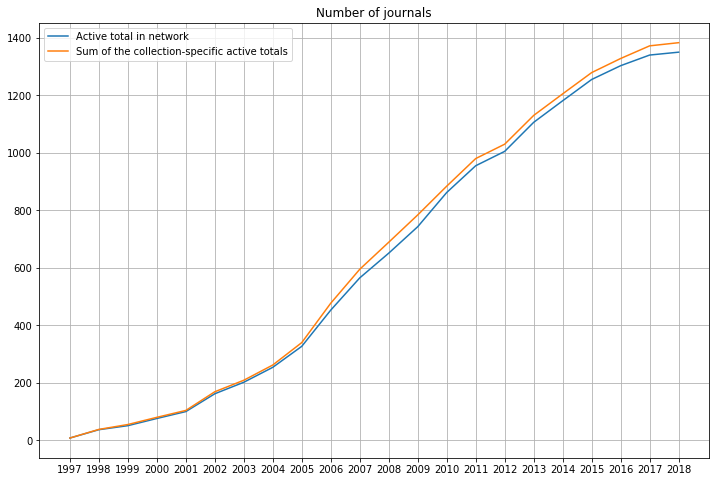

```python
pd.DataFrame({
    "Active total in network": network_index["total"],
    "Sum of the collection-specific active totals": collections_sum,
}).plot(
    figsize=(12, 8),
    title="Number of journals",
    xticks=network_index.index,
    grid=True,
);
```

The shape is almost the same, but it's a $2.44\%$ error in $2018$ (using the 2018-09-14 data).

```python
(collections_sum[2018] -
 network_index["total"][2018]) / network_index["total"][2018]
```

```
0.024444444444444446
```